# < TVING >

- 2010 : CJ 헬로비전
- 2016 : CJ E&M으로 운영사 전환
- 2020 : CJ E&M으로 부터 분할되어 TVING 설립

## 1. 장르마다의 성별 데이터

- 기간 : 2019.01.01 ~ 2022.06.30
- 장르 (4) : 영화, 드라마, 애니메이션, 예능
- 성별 (2) : 남자, 여자

```python
# 모듈 로딩
import pandas as pd
import warnings
warnings.simplefilter("ignore")
import matplotlib.pyplot as plt

# 폰트
from matplotlib import font_manager as fm, rc

font_path = './Fonts/malgun.ttf'
font_name = fm.FontProperties(fname = font_path).get_name()
rc('font', family = font_name)

# 파일 경로
DIR = '../Data_1/'
FILE_ = [ DIR+'tving_movie_M.xlsx', DIR+'tving_movie_F.xlsx', DIR+'tving_drama_M.xlsx',
         DIR+'tving_drama_F.xlsx', DIR+'tving_animation_M.xlsx', DIR+'tving_animation_F.xlsx',
         DIR+'tving_entertainment_M.xlsx', DIR+'tving_entertainment_F.xlsx' ]
# df1 -> df8 : 영화(남/여), 드라마(남/여), 애니메이션(남/여), 예능(남/여) 순서
```

```python
# 파일 로딩 -> DF 저장
df =[]
for i in FILE_:
    df.append( pd.read_excel(i, skiprows=6) )
```

### 1) 장르별 남자들의 자료

```python
# 남자의 자료들만 모아서 DF로 만들기
df[0].insert(2, '드라마_남자', df[2]['tving'])
```

```python
df[0] = pd.concat([df[0],df[4]['tving']],axis=1)
df[0] = pd.concat([df[0],df[6]['tving']],axis=1)
```

```python
df[0].columns
```

```
Index(['날짜', 'tving', '드라마_남자', 'tving', 'tving'], dtype='object')
```

```python
# 컬럼명 맞추기
df[0].columns = ['날짜', '영화', '드라마', '애니메이션', '예능']
```

```python
male_type = df[0]
male_type
```

|  | 날짜 | 영화 | 드라마 | 애니메이션 | 예능 |
| --- | --- | --- | --- | --- | --- |
| 0 | 2019-01-01 | 71.25644 | 61.61217 | 100.00000 | 65.79710 |
| 1 | 2019-01-02 | 40.62377 | 60.82245 | 62.32294 | 59.56521 |
| 2 | 2019-01-03 | 38.65465 | 48.11479 | 59.06515 | 55.50724 |
| 3 | 2019-01-04 | 46.80493 | 42.07155 | 69.40509 | 61.93236 |
| 4 | 2019-01-05 | 65.74567 | 44.94149 | 84.98583 | 59.13043 |
| ... | ... | ... | ... | ... | ... |
| 1272 | 2022-06-26 | 36.72071 | 50.64766 | 44.90084 | 45.31400 |
| 1273 | 2022-06-27 | 26.18198 | 55.05369 | 30.45325 | 51.44927 |
| 1274 | 2022-06-28 | 24.92809 | 50.87879 | 41.07648 | 54.10628 |
| 1275 | 2022-06-29 | 28.48974 | 53.82578 | 33.71104 | 48.26086 |
| 1276 | 2022-06-30 | 27.92556 | 50.61877 | 35.12747 | 48.98550 |

1277 rows × 5 columns

```python
# 정보 및 결측치 확인
male_type.info()
```

```
<class 'pandas.core.frame.DataFrame'>
RangeIndex: 1277 entries, 0 to 1276
Data columns (total 5 columns):
 #   Column  Non-Null Count  Dtype
---  ------  --------------  -----
 0   날짜      1277 non-null   object
 1   영화      1277 non-null   float64
 2   드라마     1277 non-null   float64
 3   애니메이션   1277 non-null   float64
 4   예능      1277 non-null   float64
dtypes: float64(4), object(1)
memory usage: 50.0+ KB
```

```python
male_type.isna().sum()
```

```
날짜       0
영화       0
드라마      0
애니메이션    0
예능       0
dtype: int64
```

### 2) 장르별 여자들의 자료

```python
# 여자의 자료들만 모아서 DF로 만들기
df[1].insert(2, '드라마_여자', df[3]['tving'])
```

```python
df[1] = pd.concat([df[1],df[5]['tving']],axis=1)
df[1] = pd.concat([df[1],df[7]['tving']],axis=1)
```

```python
df[1].columns
```

```
Index(['날짜', 'tving', '드라마_여자', 'tving', 'tving'], dtype='object')
```

```python
# 컬럼명 맞추기
df[1].columns = ['날짜', '영화', '드라마', '애니메이션', '예능']
```

```python
female_type = df[1]
female_type
```

|  | 날짜 | 영화 | 드라마 | 애니메이션 | 예능 |
| --- | --- | --- | --- | --- | --- |
| 0 | 2019-01-01 | 70.00321 | 67.50990 | 100.00000 | 77.14497 |
| 1 | 2019-01-02 | 40.73579 | 61.99939 | 79.96702 | 65.45857 |
| 2 | 2019-01-03 | 39.52675 | 50.99359 | 79.38994 | 60.57692 |
| 3 | 2019-01-04 | 45.40184 | 48.36025 | 82.76999 | 65.82840 |
| 4 | 2019-01-05 | 57.49518 | 45.57756 | 82.93487 | 75.44378 |
| ... | ... | ... | ... | ... | ... |
| 1272 | 2022-06-26 | 35.86458 | 62.22797 | 39.65375 | 43.86094 |
| 1273 | 2022-06-27 | 27.31951 | 71.53916 | 40.23083 | 42.52958 |
| 1274 | 2022-06-28 | 26.27182 | 63.31606 | 37.26298 | 45.93195 |
| 1275 | 2022-06-29 | 30.55385 | 67.93355 | 39.81863 | 43.93491 |
| 1276 | 2022-06-30 | 30.65679 | 66.53154 | 40.47815 | 51.84911 |

1277 rows × 5 columns

```python
# 정보 및 결측치 확인
female_type.info()
```

```
<class 'pandas.core.frame.DataFrame'>
RangeIndex: 1277 entries, 0 to 1276
Data columns (total 5 columns):
 #   Column  Non-Null Count  Dtype
---  ------  --------------  -----
 0   날짜      1277 non-null   object
 1   영화      1277 non-null   float64
 2   드라마     1277 non-null   float64
 3   애니메이션   1277 non-null   float64
 4   예능      1277 non-null   float64
dtypes: float64(4), object(1)
memory usage: 50.0+ KB
```

```python
female_type.isna().sum()
```

```
날짜       0
영화       0
드라마      0
애니메이션    0
예능       0
dtype: int64
```

## 2. 플랫폼의 연령대별 데이터

- 기간 : 2019.01.01 ~ 2022.06.30
- 플랫폼 (1) : TVING
- 연령대 (6) : 18세 이전, 20대, 30대, 40대, 50대, 60대 이상

```python
# 파일 경로
FILE_ = [ DIR+'tving_18.xlsx', DIR+'tving_20.xlsx', DIR+'tving_30.xlsx',
         DIR+'tving_40.xlsx', DIR+'tving_50.xlsx', DIR+'tving_60.xlsx']
```

```python
# 파일 로딩 -> DF 저장
ddf =[]
for i in FILE_:
    ddf.append( pd.read_excel(i, skiprows=6) )
```

```python
# 연령대별 자료 하나의 DF로 만들기
ddf[0] = pd.concat([ddf[0],ddf[1]['tving']],axis=1)
ddf[0] = pd.concat([ddf[0],ddf[2]['tving']],axis=1)
ddf[0] = pd.concat([ddf[0],ddf[3]['tving']],axis=1)
ddf[0] = pd.concat([ddf[0],ddf[4]['tving']],axis=1)
ddf[0] = pd.concat([ddf[0],ddf[5]['tving']],axis=1)
```

```python
# 컬럼명 맞추기
ddf[0].columns = ['날짜', '18세 이하', '20대', '30대', '40대', '50대', '60대 이상']
```

```python
age_tving = ddf[0]
age_tving
```

|  | 날짜 | 18세 이하 | 20대 | 30대 | 40대 | 50대 | 60대 이상 |
| --- | --- | --- | --- | --- | --- | --- | --- |
| 0 | 2019-01-01 | 4.55764 | 10.85889 | 7.65370 | 7.56159 | 9.55414 | 0.99009 |
| 1 | 2019-01-02 | 3.48525 | 11.34969 | 7.40276 | 6.37213 | 9.34182 | 5.44554 |
| 2 | 2019-01-03 | 5.63002 | 8.71165 | 6.90087 | 8.66610 | 9.76645 | 2.97029 |
| 3 | 2019-01-04 | 7.77479 | 15.52147 | 7.46549 | 10.11045 | 11.25265 | 4.45544 |
| 4 | 2019-01-05 | 10.72386 | 21.22699 | 11.48055 | 13.84876 | 9.97876 | 2.47524 |
| ... | ... | ... | ... | ... | ... | ... | ... |
| 1272 | 2022-06-26 | 3.88739 | 17.85276 | 20.13801 | 25.99830 | 27.38853 | 16.33663 |
| 1273 | 2022-06-27 | 2.54691 | 15.88957 | 16.81304 | 23.70433 | 25.05307 | 15.34653 |
| 1274 | 2022-06-28 | 3.61930 | 15.39877 | 14.80552 | 20.22090 | 22.08067 | 17.32673 |
| 1275 | 2022-06-29 | 3.21715 | 14.29447 | 16.24843 | 20.39082 | 27.60084 | 28.21782 |
| 1276 | 2022-06-30 | 4.42359 | 16.38036 | 19.63613 | 20.56074 | 26.53927 | 12.87128 |

1277 rows × 7 columns

```python
# 정보 및 결측치 확인
age_tving.info()
```

```
<class 'pandas.core.frame.DataFrame'>
RangeIndex: 1277 entries, 0 to 1276
Data columns (total 7 columns):
 #   Column  Non-Null Count  Dtype
---  ------  --------------  -----
 0   날짜      1277 non-null   object
 1   18세 이하  1277 non-null   float64
 2   20대     1277 non-null   float64
 3   30대     1277 non-null   float64
 4   40대     1277 non-null   float64
 5   50대     1277 non-null   float64
 6   60대 이상  1277 non-null   float64
dtypes: float64(6), object(1)
memory usage: 70.0+ KB
```

```python
age_tving.isna().sum()
```

```
날짜        0
18세 이하    0
20대       0
30대       0
40대       0
50대       0
60대 이상    0
dtype: int64
```

## 3. 분석 내용

### 1) 장르 & 남자들의 데이터 연도별 그룹화 후, 평균값

```python
male_type['날짜'].str.split('-', expand=True)
```

|  | 0 | 1 | 2 |
| --- | --- | --- | --- |
| 0 | 2019 | 01 | 01 |
| 1 | 2019 | 01 | 02 |
| 2 | 2019 | 01 | 03 |
| 3 | 2019 | 01 | 04 |
| 4 | 2019 | 01 | 05 |
| ... | ... | ... | ... |
| 1272 | 2022 | 06 | 26 |
| 1273 | 2022 | 06 | 27 |
| 1274 | 2022 | 06 | 28 |
| 1275 | 2022 | 06 | 29 |
| 1276 | 2022 | 06 | 30 |

1277 rows × 3 columns

```python
male_type1 = pd.concat([male_type, male_type['날짜'].str.split('-', expand=True)], axis=1)
```

```python
male_type1.rename(columns={0:'Y',1:'M',2:'D'},inplace=True)
```

```python
male_type1 = male_type1.groupby(['Y']).agg('mean')
```

```python
male_type1
```

| Y | 영화 | 드라마 | 애니메이션 | 예능 |
| --- | --- | --- | --- | --- |
| 2019 | 46.234216 | 49.799868 | 51.280215 | 55.631919 |
| 2020 | 27.387658 | 57.591261 | 49.296811 | 65.772414 |
| 2021 | 21.450900 | 50.354344 | 43.404473 | 56.659911 |
| 2022 | 25.024896 | 49.395618 | 39.323551 | 47.534091 |

### 2) 장르 & 여자들의 데이터 연도별 그룹화 후, 평균값

```python
female_type['날짜'].str.split('-', expand=True)
```

|  | 0 | 1 | 2 |
| --- | --- | --- | --- |
| 0 | 2019 | 01 | 01 |
| 1 | 2019 | 01 | 02 |
| 2 | 2019 | 01 | 03 |
| 3 | 2019 | 01 | 04 |
| 4 | 2019 | 01 | 05 |
| ... | ... | ... | ... |
| 1272 | 2022 | 06 | 26 |
| 1273 | 2022 | 06 | 27 |
| 1274 | 2022 | 06 | 28 |
| 1275 | 2022 | 06 | 29 |
| 1276 | 2022 | 06 | 30 |

1277 rows × 3 columns

```python
female_type1 = pd.concat([female_type, male_type['날짜'].str.split('-', expand=True)], axis=1)
```

```python
female_type1.rename(columns={0:'Y',1:'M',2:'D'},inplace=True)
```

```python
female_type1 = female_type1.groupby(['Y']).agg('mean')
```

```python
female_type1
```

| Y | 영화 | 드라마 | 애니메이션 | 예능 |
| --- | --- | --- | --- | --- |
| 2019 | 42.177536 | 51.512297 | 51.733386 | 60.504372 |
| 2020 | 24.216511 | 62.968844 | 54.370228 | 67.632242 |
| 2021 | 20.862896 | 60.103346 | 49.528053 | 56.101965 |
| 2022 | 24.342100 | 63.716150 | 45.010994 | 45.066032 |

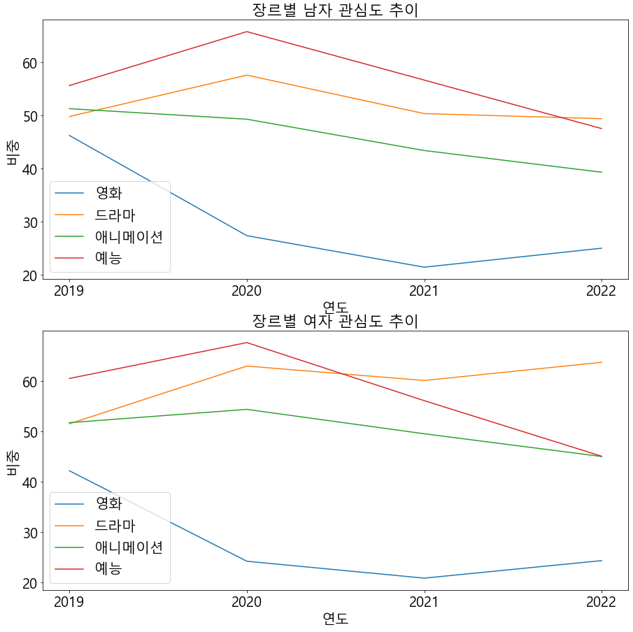

```python
fig = plt.figure(figsize=(15,15))

plt.subplot(211)
plt.plot(male_type1)
plt.title("장르별 남자 관심도 추이")
plt.xlabel("연도")
plt.ylabel("비중")
plt.legend(['영화','드라마','애니메이션','예능'])

plt.subplot(212)
plt.plot(female_type1)
plt.title("장르별 여자 관심도 추이")
plt.xlabel("연도")
plt.ylabel("비중")
plt.legend(['영화','드라마','애니메이션','예능'])

plt.show()
```

```python
# 장르별 남성 데이터 연, 월까지의 그룹화
male_type6 = pd.concat([male_type, male_type['날짜'].str.split('-', expand=True)], axis=1)
male_type6.rename(columns={0:'Y',1:'M',2:'D'},inplace=True)
male_type6 = male_type6.groupby(['Y','M']).agg('mean')
male_type6
```

| Y | M | 영화 | 드라마 | 애니메이션 | 예능 |
| --- | --- | --- | --- | --- | --- |
| 2019 | 01 | 49.025494 | 45.053794 | 67.467782 | 55.482307 |
|  | 02 | 50.352435 | 52.197506 | 55.524075 | 55.660796 |
|  | 03 | 44.518411 | 49.079411 | 49.328333 | 57.109236 |
|  | 04 | 39.557133 | 46.787847 | 47.837578 | 52.684374 |
|  | 05 | 37.310034 | 46.949483 | 47.980438 | 52.063266 |
|  | 06 | 39.696799 | 44.803289 | 53.002827 | 52.964568 |
|  | 07 | 44.266401 | 54.620771 | 55.473813 | 59.328342 |
|  | 08 | 51.088454 | 46.914687 | 47.071183 | 64.829353 |
|  | 09 | 55.487148 | 49.718459 | 43.508021 | 58.078900 |
|  | 10 | 46.849734 | 53.054857 | 45.106456 | 53.161908 |
|  | 11 | 45.626997 | 47.527482 | 50.854574 | 51.323668 |
|  | 12 | 51.282706 | 60.788591 | 52.298267 | 54.657935 |
| 2020 | 01 | 53.908824 | 57.934031 | 50.022840 | 58.290473 |
|  | 02 | 40.286001 | 69.712719 | 51.846238 | 60.891216 |
|  | 03 | 25.126261 | 72.333116 | 53.157264 | 73.721360 |
|  | 04 | 18.809790 | 63.213748 | 55.915953 | 72.148143 |
|  | 05 | 18.481508 | 52.582488 | 52.234300 | 65.605419 |
|  | 06 | 23.175293 | 46.786082 | 49.999995 | 63.017709 |
|  | 07 | 27.284735 | 49.619505 | 45.951745 | 63.657468 |
|  | 08 | 31.871000 | 48.596792 | 49.579635 | 73.822654 |
|  | 09 | 23.489823 | 52.506375 | 46.883848 | 73.441219 |
|  | 10 | 26.832420 | 56.217132 | 41.117604 | 61.972880 |
|  | 11 | 23.536171 | 53.177472 | 44.551459 | 57.922701 |
|  | 12 | 16.019653 | 68.724103 | 50.470616 | 64.573783 |
| 2021 | 01 | 13.897735 | 53.897229 | 47.884487 | 66.805356 |
|  | 02 | 18.036437 | 65.138883 | 48.507684 | 61.777082 |
|  | 03 | 15.903203 | 58.556607 | 46.696514 | 54.248085 |
|  | 04 | 16.321830 | 51.308642 | 47.440977 | 56.318835 |
|  | 05 | 19.487704 | 56.682822 | 48.857712 | 56.013709 |
|  | 06 | 22.013757 | 49.031471 | 44.334272 | 50.793876 |
|  | 07 | 26.918545 | 40.691259 | 44.576437 | 60.091938 |
|  | 08 | 28.450496 | 39.397798 | 41.620208 | 62.055472 |
|  | 09 | 25.993369 | 50.233699 | 36.194519 | 56.925921 |
|  | 10 | 22.387033 | 42.397130 | 36.109836 | 55.448023 |
|  | 11 | 25.591223 | 47.650113 | 39.150136 | 49.847016 |
|  | 12 | 22.211825 | 50.594222 | 39.765141 | 49.677414 |
| 2022 | 01 | 23.065105 | 50.807651 | 40.258608 | 48.772007 |
|  | 02 | 22.347134 | 46.206373 | 39.270533 | 53.780188 |
|  | 03 | 21.535867 | 47.876666 | 39.851955 | 49.918960 |
|  | 04 | 25.501193 | 51.531272 | 37.455141 | 42.573264 |
|  | 05 | 26.417838 | 46.067655 | 39.047787 | 43.021655 |
|  | 06 | 31.238916 | 53.785970 | 40.014158 | 47.584536 |

```python
# 장르별 여성 데이터 연, 월까지의 그룹화
female_type5 = pd.concat([female_type, male_type['날짜'].str.split('-', expand=True)], axis=1)
female_type5.rename(columns={0:'Y',1:'M',2:'D'},inplace=True)
female_type5 = female_type5.groupby(['Y','M']).agg('mean')
```

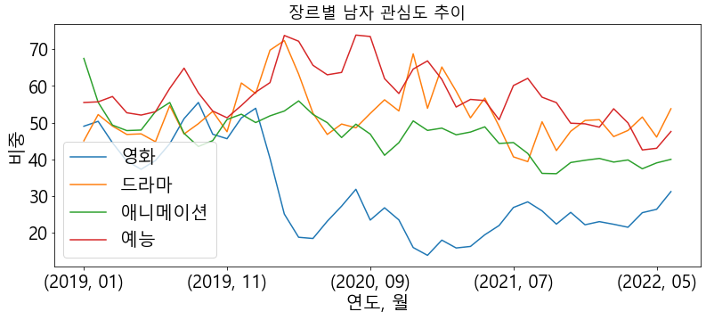

```python
male_type6.plot(figsize=(13,5))

plt.rc('font', size=15)        # 기본 폰트 크기
plt.rc('axes', labelsize=18)   # x,y축 label 폰트 크기
plt.rc('xtick', labelsize=15)  # x축 눈금 폰트 크기
plt.rc('ytick', labelsize=15)  # y축 눈금 폰트 크기
plt.rc('legend', fontsize=15)  # 범례 폰트 크기
plt.rc('figure', titlesize=15) # figure title 폰트 크기


plt.title("장르별 남자 관심도 추이")
plt.xlabel("연도, 월")
plt.ylabel("비중")
plt.show()
```

[output not shown]

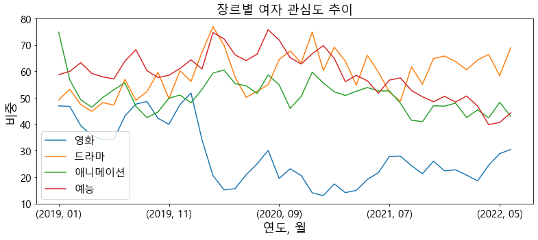

```python
female_type5.plot(figsize=(13,5))

plt.rc('font', size=15)        # 기본 폰트 크기
plt.rc('axes', labelsize=18)   # x,y축 label 폰트 크기
plt.rc('xtick', labelsize=15)  # x축 눈금 폰트 크기
plt.rc('ytick', labelsize=15)  # y축 눈금 폰트 크기
plt.rc('legend', fontsize=15)  # 범례 폰트 크기
plt.rc('figure', titlesize=15) # figure title 폰트 크기


plt.title("장르별 여자 관심도 추이")
plt.xlabel("연도, 월")
plt.ylabel("비중")
plt.show()
```

### 3) 연도별 연령대의 연도별 그룹화 후, 평균값

```python
age_tving['날짜'].str.split('-', expand=True)
```

|  | 0 | 1 | 2 |
| --- | --- | --- | --- |
| 0 | 2019 | 01 | 01 |
| 1 | 2019 | 01 | 02 |
| 2 | 2019 | 01 | 03 |
| 3 | 2019 | 01 | 04 |
| 4 | 2019 | 01 | 05 |
| ... | ... | ... | ... |
| 1272 | 2022 | 06 | 26 |
| 1273 | 2022 | 06 | 27 |
| 1274 | 2022 | 06 | 28 |
| 1275 | 2022 | 06 | 29 |
| 1276 | 2022 | 06 | 30 |

1277 rows × 3 columns

```python
age_tving1 = pd.concat([age_tving, age_tving['날짜'].str.split('-', expand=True)], axis=1)
```

```python
age_tving1.rename(columns={0:'Y',1:'M',2:'D'},inplace=True)
```

```python
age_tving1 = age_tving1.groupby(['Y']).agg('mean')
```

```python
age_tving1
```

| Y | 18세 이하 | 20대 | 30대 | 40대 | 50대 | 60대 이상 |
| --- | --- | --- | --- | --- | --- | --- |
| 2019 | 5.855884 | 13.352041 | 7.546789 | 8.261538 | 7.239037 | 4.519186 |
| 2020 | 8.986722 | 16.432829 | 10.701670 | 13.178354 | 12.698242 | 7.233670 |
| 2021 | 10.403976 | 22.952008 | 18.980762 | 21.764174 | 20.935922 | 11.487857 |
| 2022 | 5.968475 | 15.410293 | 18.324236 | 24.170444 | 27.394395 | 16.002949 |

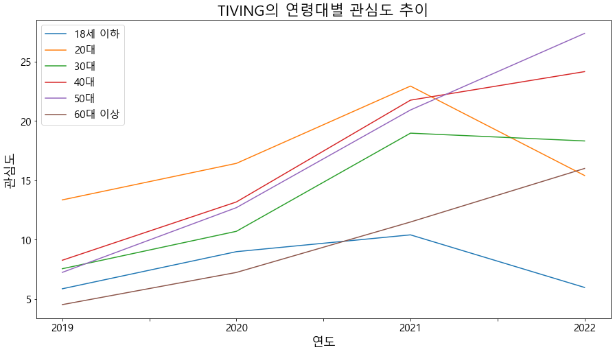

```python
age_tving1.plot(figsize=(15,8))

plt.rc('font', size=18)        # 기본 폰트 크기
plt.rc('axes', labelsize=20)   # x,y축 label 폰트 크기
plt.rc('xtick', labelsize=20)  # x축 눈금 폰트 크기
plt.rc('ytick', labelsize=20)  # y축 눈금 폰트 크기
plt.rc('legend', fontsize=20)  # 범례 폰트 크기
plt.rc('figure', titlesize=20) # figure title 폰트 크기

plt.title("TIVING의 연령대별 관심도 추이")
plt.xlabel("연도")
plt.ylabel("관심도")

plt.show()
```

```python
# 연령대별 데이터 연, 월까지의 그룹화
age_tving3 = pd.concat([age_tving, age_tving['날짜'].str.split('-', expand=True)], axis=1)
age_tving3.rename(columns={0:'Y',1:'M',2:'D'},inplace=True)
age_tving3 = age_tving3.groupby(['Y','M']).agg('mean')
age_tving3
```

| Y | M | 18세 이하 | 20대 | 30대 | 40대 | 50대 | 60대 이상 |
| --- | --- | --- | --- | --- | --- | --- | --- |
| 2019 | 01 | 5.608401 | 12.926969 | 7.949159 | 9.381419 | 9.615775 | 4.758858 |
|  | 02 | 5.203940 | 9.956174 | 6.414675 | 7.755791 | 7.150435 | 3.960390 |
|  | 03 | 4.064685 | 9.922812 | 5.304160 | 5.769172 | 5.616048 | 3.129984 |
|  | 04 | 3.025017 | 9.069524 | 5.022998 | 5.564991 | 5.180462 | 4.224416 |
|  | 05 | 6.023518 | 14.167815 | 6.937300 | 7.049082 | 6.807748 | 3.656972 |
|  | 06 | 5.898119 | 16.707562 | 8.308234 | 8.246951 | 6.737433 | 3.795373 |
|  | 07 | 8.765022 | 16.665342 | 8.368070 | 9.101867 | 7.526876 | 4.247838 |
|  | 08 | 10.598455 | 16.748462 | 9.046014 | 10.121409 | 7.924109 | 5.301816 |
|  | 09 | 7.435205 | 16.764820 | 10.361769 | 10.804300 | 7.558381 | 5.148510 |
|  | 10 | 4.194408 | 12.776563 | 7.991657 | 8.120695 | 7.047458 | 4.774827 |
|  | 11 | 3.668449 | 11.216764 | 6.999159 | 7.754172 | 7.169139 | 4.917486 |
|  | 12 | 5.612725 | 12.984360 | 7.765001 | 9.397863 | 8.451470 | 6.259976 |
| 2020 | 01 | 6.473227 | 14.367696 | 10.448451 | 13.051219 | 12.341616 | 7.537524 |
|  | 02 | 7.927333 | 17.262529 | 14.132734 | 15.750149 | 15.681963 | 8.364626 |
|  | 03 | 9.746601 | 18.133776 | 12.708944 | 15.199929 | 14.368874 | 7.473647 |
|  | 04 | 9.209111 | 18.114515 | 11.865324 | 14.483144 | 13.757956 | 6.831680 |
|  | 05 | 9.037442 | 17.326335 | 10.579993 | 13.385584 | 13.060745 | 7.186198 |
|  | 06 | 5.384267 | 13.022490 | 8.412793 | 11.220612 | 11.599429 | 6.303626 |
|  | 07 | 4.665740 | 10.870764 | 8.036179 | 10.351627 | 10.355449 | 6.930689 |
|  | 08 | 5.262469 | 11.515926 | 8.665556 | 11.023100 | 10.958148 | 5.956559 |
|  | 09 | 6.041104 | 13.177909 | 9.458380 | 12.095718 | 11.408346 | 7.112208 |
|  | 10 | 10.321711 | 19.042148 | 10.213699 | 12.900480 | 12.622418 | 5.828804 |
|  | 11 | 11.626448 | 19.693247 | 10.671261 | 12.022085 | 10.976641 | 7.013198 |
|  | 12 | 21.957964 | 24.664550 | 13.370699 | 16.729241 | 15.341409 | 10.284248 |
| 2021 | 01 | 13.638324 | 20.769836 | 16.394134 | 21.289768 | 22.210802 | 9.948894 |
|  | 02 | 13.112787 | 17.353194 | 12.652353 | 18.424560 | 20.351830 | 9.529700 |
|  | 03 | 7.476429 | 15.739160 | 13.299869 | 16.866277 | 18.204227 | 9.789200 |
|  | 04 | 7.225196 | 15.433533 | 12.693428 | 17.652218 | 18.018395 | 9.950490 |
|  | 05 | 8.349904 | 18.850183 | 16.734118 | 18.987579 | 16.622144 | 9.038642 |
|  | 06 | 8.534401 | 27.370138 | 27.783349 | 28.249782 | 25.732478 | 18.498345 |
|  | 07 | 10.166042 | 24.676425 | 20.882741 | 21.530951 | 20.978010 | 12.919190 |
|  | 08 | 10.166041 | 25.493761 | 19.415545 | 21.289769 | 20.964313 | 11.593736 |
|  | 09 | 9.982122 | 30.288337 | 22.162270 | 22.596994 | 21.578197 | 13.184814 |
|  | 10 | 11.186539 | 29.499303 | 20.516448 | 20.733407 | 20.498592 | 12.519957 |
|  | 11 | 11.773900 | 26.531692 | 24.905892 | 28.433866 | 23.814573 | 10.693065 |
|  | 12 | 13.365904 | 23.128829 | 20.091467 | 25.110308 | 22.375175 | 10.204403 |
| 2022 | 01 | 8.574759 | 17.359980 | 20.184557 | 28.533445 | 31.141698 | 18.428612 |
|  | 02 | 8.248749 | 16.860206 | 19.658536 | 27.033009 | 29.845309 | 17.591933 |
|  | 03 | 5.915415 | 17.650895 | 18.411781 | 23.394629 | 27.237855 | 14.931327 |
|  | 04 | 3.882926 | 12.310835 | 16.369716 | 21.234773 | 23.064397 | 12.326728 |
|  | 05 | 4.324133 | 12.457941 | 16.428537 | 19.930381 | 22.847745 | 11.705521 |
|  | 06 | 4.986590 | 15.877296 | 18.979501 | 25.109029 | 30.424623 | 21.237619 |

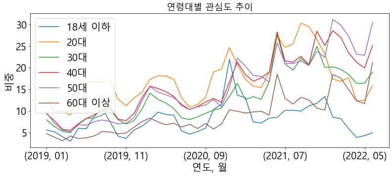

```python
age_tving3.plot(figsize=(13,5))

plt.rc('font', size=15)        # 기본 폰트 크기
plt.rc('axes', labelsize=18)   # x,y축 label 폰트 크기
plt.rc('xtick', labelsize=15)  # x축 눈금 폰트 크기
plt.rc('ytick', labelsize=15)  # y축 눈금 폰트 크기
plt.rc('legend', fontsize=15)  # 범례 폰트 크기
plt.rc('figure', titlesize=15) # figure title 폰트 크기


plt.title("연령대별 관심도 추이")
plt.xlabel("연도, 월")
plt.ylabel("비중")
plt.show()
```

## 4. 총평

- 성별에 대한 관심도의 증감 여부는 작품들. 즉, 콘텐츠들의 인기도에 따라 유동적으로 변하는 것으로 보임  
  -> 양질의 콘텐츠를 제작하는 것에 집중

< STP >

- Segmentaion (소비자층 구분)
  - 성별에 따른 장르의 관심도 등락폭은 서비스하는 작품에 따른 변동성이 큰 것으로 볼 수 있음 (비교해 봤을 때도)
  - 성별보다는 연령대에 맞춘 마케팅 전략을 통한 성과를 노려봅시다.
- Targeting (핵심 소비자층)
  - 관심도가 하락하는 젊은 세대
  - 'A세대' : 높은 구매력으로 여유로운 장밋빛 인생 2막을 시작한 50~69세 시니어(Senior)를 의미  
    -> 유행에 민감하지 않고, 높은 충성도/구매력, 새 IT 기기 구매 등  
    -> ex) 임영웅의 음악 플랫폼 상위 랭크, 팬들 조공 문화, 단독 콘서트 매진
- Positioning (국내시장, A세대)
  - '국내, A세대를 위한 콘텐츠 및 서비스의 강자' 라는 콘셉으로 방향 설정
  - CJ 계열, 2010년부터 누적된 국내 고객 정보 확보, JTBC, 네이버의 합류 => 국내 시장에서의 강점
  - 강점을 살려 -> ex) 실제, 티빙에서 임영웅의 서울 공연을 중계 해주기도 했다고 함

## 5. 부족

- 객관성을 강화할 수 있는 자료들을 추가한 상태에서 비교
- 그래프 사용법을 숙지하여 다양한 시각화 자료를 출력할 수 있도록